# Industry 4.0 의 중심, BigData

Data Processing Based Python @ [FB / jskim.kr](https://www.facebook.com/jskim.kr), [김진수](bigpycraft@gmail.com)

## 주석 사용

### 제목 추가

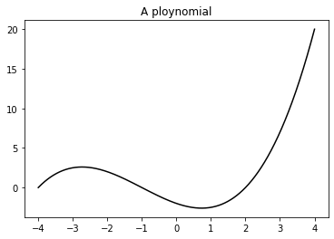

```python
# pyplot.title() : 그래픽에 제목을 추가
import numpy as np
import matplotlib.pyplot as plt

X = np.linspace(-4, 4, 1024)
Y = .25 * (X + 4.) * (X + 1.) * (X - 2.)

plt.title('A ploynomial')
plt.plot(X, Y, c='k')
plt.show()
```

### 라텍스 스타일 표기법 사용

#### 그림에 수학적 스크립트를 표시하기 위해 라텍스(LaTex)를 사용하는 방법

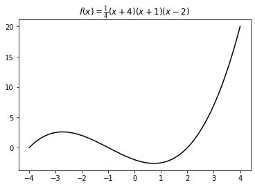

```python
# 제목을 라텍스로 랜더링했으며, 수학적인 표기법을 사용할 수 있다.
import numpy as np
import matplotlib.pyplot as plt

X = np.linspace(-4, 4, 1024)
Y = .25 * (X + 4.) * (X + 1.) * (X - 2.)

plt.title('$f(x)=\\frac{1}{4}(x+4)(x+1)(x-2)$')
plt.plot(X, Y, c='k')
plt.show()
```

### 각 축에 레이블 추가

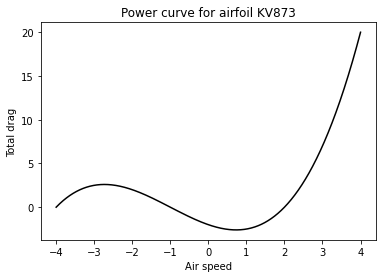

```python
# pyplot.xlabel(), pyplot.ylabel() : 수평축과 수직축의 기술 추가
import numpy as np
import matplotlib.pyplot as plt

X = np.linspace(-4, 4, 1024)
Y = .25 * (X + 4.) * (X + 1.) * (X - 2.)

plt.title('Power curve for airfoil KV873')
plt.xlabel('Air speed')
plt.ylabel('Total drag')
plt.plot(X, Y, c='k')
plt.show()
```

### 텍스트 추가

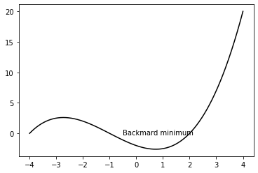

```python
# pyplot.text() : 멧플롯립에 텍스트를 표시
import numpy as np
import matplotlib.pyplot as plt

X = np.linspace(-4, 4, 1024)
Y = .25 * (X + 4.) * (X + 1.) * (X - 2.)

plt.text(-0.5, -0.25, 'Backmard minimum')

plt.plot(X, Y, c='k')
plt.show()
```

### 정렬 제어

##### 수직 정렬 옵션

> • center : 텍스트 상자의 가운데와 관련 있다.  
> • top : 텍스트 상자의 위쪽과 관련 있다.  
> • bottom : 텍스트 상자의 아래쪽과 관련 있다.  
> • baseline : 텍스트의 기준선과 관련 있다.

##### 수평 정렬 옵션

> • center : 텍스트 상자의 가운데와 관련 있다.  
> • left : 텍스트 상자의 왼쪽과 관련 있다.  
> • right : 텍스트 상자의 오른쪽과 관련 있다.

### bbox 파라미터

> • facecolor : 상자에 사용하는 컬러  
> • edgecolor : 상자 모양의 에지에 사용하는 컬러  
> • alpha : 상자와 배경을 혼합하기 위해 투명도를 설정할 때 사용  
> • boxstyle : round와 square 중 하나로 상자 스타일을 설정  
> • pad : boxstyle을 square로 설정할 때, 텍스트와 상자 옆 사이를 채울 용량을 정의

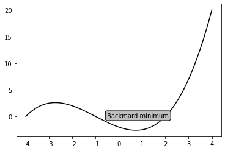

```python
# pyplot.text() 함수는 딕셔너리를 입력으로 취하는 bbox 파라미터를 지원한다.
import numpy as np
import matplotlib.pyplot as plt

X = np.linspace(-4, 4, 1024)
Y = .25 * (X + 4.) * (X + 1.) * (X - 2.)

box = {
    'facecolor' : '.75',
    'edgecolor' : 'k',
    'boxstyle'  : 'round'
}

plt.text(-0.5, -0.20, 'Backmard minimum', bbox=box)

plt.plot(X, Y, c='k')
plt.show()
```

### 화살표 추가

arrowprops 파라미터  
• arrowstyle : '<-', '<', '-', 'wedge', 'fancy', 'simple'  
• facecolor : 화살표에 사용하는 컬러  
• edgecolor : 화살표 모양의 가장자리에 사용하는 컬러  
• alpha : 화살표와 배겨을 혼합하기 위해 투명도를 설정할 때 사용

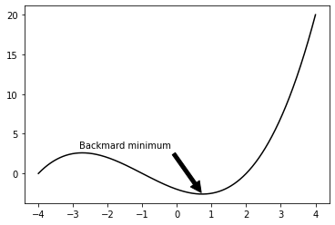

```python
# pyplot.annotate() : 화살표를 그리는 함수
import numpy as np
import matplotlib.pyplot as plt

X = np.linspace(-4, 4, 1024)
Y = .25 * (X + 4.) * (X + 1.) * (X - 2.)

plt.annotate('Backmard minimum',
            ha = 'center',
            va = 'bottom',
            xytext = (-1.5, 3.),
            xy = (0.75, -2.7),
            arrowprops = { 'facecolor' : 'black',
                           'shrink' : 0.05})

plt.plot(X, Y, c='k')
plt.show()
```

### 범례 추가

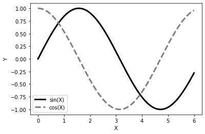

```python
# pyplot.legend() :
import numpy as np
import matplotlib.pyplot as plt

X = np.linspace(0, 6, 1024)
Y1 = np.sin(X)
Y2 = np.cos(X)

plt.xlabel('X')
plt.ylabel('Y')

plt.plot(X, Y1, c='k', lw=3., label='sin(X)')
plt.plot(X, Y2, c='.5', lw=3., ls='--', label='cos(X)')

plt.legend()
plt.show()
```

### 격자 추가

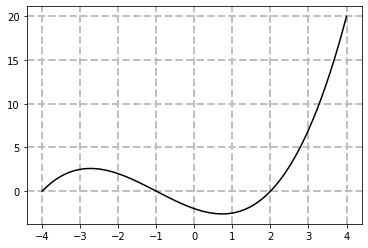

```python
# pyplot.grid() : 맷플롯립의 격자 기능을 제어
import numpy as np
import matplotlib.pyplot as plt

X = np.linspace(-4, 4, 1024)
Y = .25 * (X + 4.) * (X + 1.) * (X - 2.)

plt.plot(X, Y, c='k')
plt.grid(True, lw=2, ls='--', c='.75')
plt.show()
```

### 선 추가

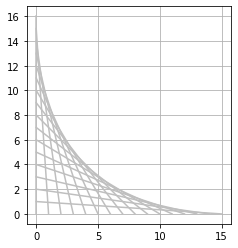

```python
# 대부분 맷플롯립 플롯팅 함수는 선과 모양 집합을 반환함을 언급
# pyplot.Line2D() : 선을 만들지만, 직접 명시적으로 요청하기까지는 선을 랜더링하지 않음
import matplotlib.pyplot as plt

N = 16
for i in range(N):
    plt.gca().add_line(plt.Line2D((0, i), (N-i, 0), color='.75'))

plt.grid(True)
plt.axis('scaled')
plt.show()
```

### 모양 추가

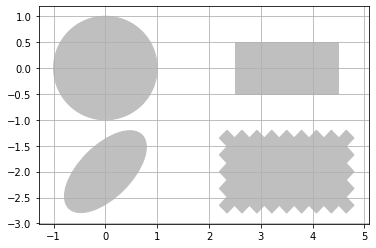

```python
# 그림에 모양을 추가하는 방법
import matplotlib.patches as patches
import matplotlib.pyplot as plt

# 원
shape = patches.Circle((0, 0), radius=1., color='.75')
plt.gca().add_patch(shape)

# 직사각형
shape = patches.Rectangle((2.5, -.5), 2., 1., color='.75')
plt.gca().add_patch(shape)

# 타원
shape = patches.Ellipse((0, -2.), 2., 1., angle=45., color='.75')
plt.gca().add_patch(shape)

# 장식상자
shape = patches.FancyBboxPatch((2.5, -2.5), 2., 1., boxstyle='sawtooth', color='.75')
plt.gca().add_patch(shape)

# 모두 표시
plt.grid()
plt.axis('scaled')
plt.show()
```

### 다각형으로 작업

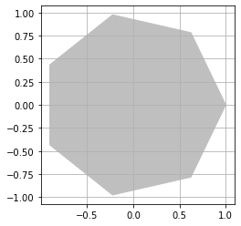

```python
# 점 목록으로 정의되는 다각형은 대부분 경로보다 더 복잡
import numpy as np
import matplotlib.patches as patches
import matplotlib.pyplot as plt

theta = np.linspace(0, 2*np.pi, 8)
points = np.vstack((np.cos(theta), np.sin(theta))).transpose()

plt.gca().add_patch(patches.Polygon(points, color='.75'))

plt.grid(True)
plt.axis('scaled')
plt.show()
```

### 경로 속성으로 작업

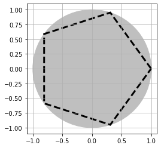

```python
# 모든 경로는 linewidth, linestyle, edgecolor, facecolor, hatch 등인 여러 속성 가짐
import numpy as np
import matplotlib.patches as patches
import matplotlib.pyplot as plt

theta = np.linspace(0, 2*np.pi, 6)
points = np.vstack((np.cos(theta), np.sin(theta))).transpose()

plt.gca().add_patch(plt.Circle((0, 0), radius=1., color='.75'))
plt.gca().add_patch(plt.Polygon(points, closed=None, fill=None, lw=3., ls='dashed', edgecolor='k'))

plt.grid(True)
plt.axis('scaled')
plt.show()
```

### 눈금 간격 제어

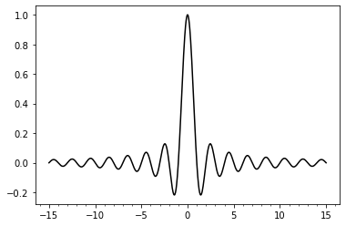

```python
# x축의 눈금 사이 간격을 조작
import numpy as np
import matplotlib.ticker as ticker
import matplotlib.pyplot as plt

X = np.linspace(-15, 15, 1024)
Y = np.sinc(X)

ax = plt.axes()
ax.xaxis.set_major_locator(ticker.MultipleLocator(5))
ax.xaxis.set_minor_locator(ticker.MultipleLocator(1))

plt.plot(X, Y, c='k')
plt.show()
```

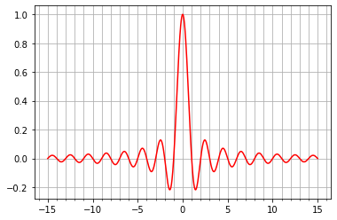

```python
# 격자를 추가하고 싶다면, 다음과 같이 작은 눈금을 고려할 수 있다.
import numpy as np
import matplotlib.pyplot as plt
import matplotlib.ticker as ticker

X = np.linspace(-15, 15, 1024)
Y = np.sinc(X)

ax = plt.axes()
ax.xaxis.set_major_locator(ticker.MultipleLocator(5))
ax.xaxis.set_minor_locator(ticker.MultipleLocator(1))

plt.grid(True, which='both')
plt.plot(X, Y, c='r')
plt.show()
```

### 눈금 레이블 붙이기 제어

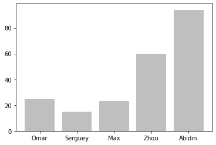

```python
# 표준 맷플롯립 눈금 API를 사용해 막대 차트의 눈금을 설정하는 작업
# ticker.Locatoer : 눈금의 위치를 생성
# ticker.Formatter : 눈금용 레이블을 생성
import numpy as np
import matplotlib.ticker as ticker
import matplotlib.pyplot as plt

name_list  = ('Omar', 'Serguey', 'Max', 'Zhou', 'Abidin')
value_list = np.random.randint(0, 99, size=len(name_list))
pos_list   = np.arange(len(name_list))

ax = plt.axes()
ax.xaxis.set_major_locator(ticker.FixedLocator((pos_list)))
ax.xaxis.set_major_formatter(ticker.FixedFormatter((name_list)))

plt.bar(pos_list, value_list, color='.75', align='center')
plt.show()
```

### 고정 레이블이 있는 막대 차트를 생성하는 더 간편한 방법

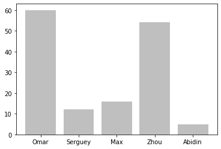

```python
# 막대 차트의 고정 레이블에 관한 특정한 경우에서 축약어를 활용
import numpy as np
import matplotlib.pyplot as plt

name_list  = ('Omar', 'Serguey', 'Max', 'Zhou', 'Abidin')
value_list = np.random.randint(0, 99, size=len(name_list))
pos_list   = np.arange(len(name_list))

plt.bar(pos_list, value_list, color='.75', align='center')
plt.xticks(pos_list, name_list)
plt.show()
```

### 고급 레이블 생성

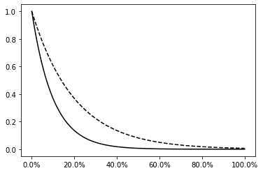

```python
# 눈금 API의 핵심이 레이블에 관련한 축약어
import numpy as np
import matplotlib.ticker as ticker
import matplotlib.pyplot as plt

def make_label(value, pos):
    return '%0.1f%%' % (100. * value)

ax = plt.axes()
ax.xaxis.set_major_formatter(ticker.FuncFormatter(make_label))

X = np.linspace(0, 1, 256)

plt.plot(X, np.exp(-10*X), c='k')
plt.plot(X, np.exp(-5*X), c='k', ls='--')
plt.show()
```

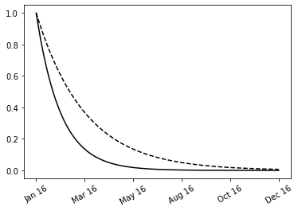

```python
# 눈금 API의 핵심이 레이블에 관련한 축약어
import numpy as np
import datetime
import matplotlib.ticker as ticker
import matplotlib.pyplot as plt

start_date = datetime.datetime(2016, 1, 1)

def make_label(value, pos):
    time = start_date + datetime.timedelta(days = 365 * value)
    return time.strftime('%b %y')

ax = plt.axes()
ax.xaxis.set_major_formatter(ticker.FuncFormatter(make_label))

X = np.linspace(0, 1, 256)

plt.plot(X, np.exp(-10*X), c='k')
plt.plot(X, np.exp(-5*X), c='k', ls='--')

labels = ax.get_xticklabels()
plt.setp(labels, rotation=30.)
plt.show()
```

The BigpyCraft find the information to design valuable society with Technology & Craft.

< The End >